# Analyzing CFM data (version 2)

Leandro Ledesma

2024-12-19

### Universal block code settings

### Load in the data

We will be loading the CFM2-4 and the CFM5-17 separately. These data are fixed so no new screeners will be introduced into these datasets from the on going data collection.

### Preparing data

- We will be keep variables of interest which include:
- Level of reported difficulty for each domain for both screeners
- The child_ID, which will be given a random intercept
- The HOH_ID, which will be given a random intercept
- Age and Sex
- Their DD status as a ‘at least some difficulty’, ‘at least a lot of difficulty’, ‘cannot at all’
- Accessibility to assisting equipment

### Data Cleaning

- We need to remove incorrectly used screeners
- Additionally we need to check for anything that indicates bad data (wrong ages, etc.)
- Two data points are missing for 2 IDs but they will be kept since it is missing data for glasses/hearing aids.

```
   Min. 1st Qu.  Median    Mean 3rd Qu.    Max.
   2.10    3.50    3.90    3.93    4.40    5.00
```

```
   Min. 1st Qu.  Median    Mean 3rd Qu.    Max.
   4.60    8.20   11.00   11.19   14.20   19.00
```

```
[1] 0
```

```
[1] 2
```

### Obtain descriptive statistics for both screener types

```
[1] 301
```

```
[1] 301
```

```
   Min. 1st Qu.  Median    Mean 3rd Qu.    Max.
   2.10    3.50    3.90    3.93    4.40    5.00
```

```
female   male
   160    141
```

```
[1] 2738
```

```
[1] 2738
```

```
   Min. 1st Qu.  Median    Mean 3rd Qu.    Max.
   4.60    8.20   11.00   11.19   14.20   19.00
```

```
female   male
  1338   1400
```

## Part 1: Prevalence of DD by different threshold for both screeners

```
 No_difficulty    at_least_some_diff at_least_alot_diff cannot_at_all_diff
 Min.   :0.0000   Min.   :0.0000     Min.   :0.00000    Min.   :0.00000
 1st Qu.:1.0000   1st Qu.:0.0000     1st Qu.:0.00000    1st Qu.:0.00000
 Median :1.0000   Median :0.0000     Median :0.00000    Median :0.00000
 Mean   :0.8206   Mean   :0.1794     Mean   :0.05648    Mean   :0.01329
 3rd Qu.:1.0000   3rd Qu.:0.0000     3rd Qu.:0.00000    3rd Qu.:0.00000
 Max.   :1.0000   Max.   :1.0000     Max.   :1.00000    Max.   :1.00000
```

```
 No_difficulty    at_least_some_diff_weekly at_least_alot_diff_weekly
 Min.   :0.0000   Min.   :0.0000            Min.   :0.0000
 1st Qu.:0.0000   1st Qu.:0.0000            1st Qu.:0.0000
 Median :1.0000   Median :0.0000            Median :0.0000
 Mean   :0.7115   Mean   :0.2885            Mean   :0.1234
 3rd Qu.:1.0000   3rd Qu.:1.0000            3rd Qu.:0.0000
 Max.   :1.0000   Max.   :1.0000            Max.   :1.0000
 cannot_diff_daily
 Min.   :0.00000
 1st Qu.:0.00000
 Median :0.00000
 Mean   :0.02228
 3rd Qu.:0.00000
 Max.   :1.00000
```

|  | % (95% CI) |
| --- | --- |
| No_difficulty | 82.06 (77.73, 86.39) |
| at_least_some_diff | 17.94 (13.61, 22.27) |
| at_least_alot_diff | 5.65 (3.04, 8.26) |
| cannot_at_all_diff | 1.33 (0.04, 2.62) |

|  | % (95% CI) |
| --- | --- |
| No_difficulty | 71.15 (69.44, 72.86) |
| at_least_some_diff_weekly | 28.85 (27.14, 30.56) |
| at_least_alot_diff_weekly | 12.34 (11.11, 13.57) |
| cannot_diff_daily | 2.23 (1.68, 2.78) |

## Plotting descriptives of Reported Difficulties by Domain (CFM2-4)

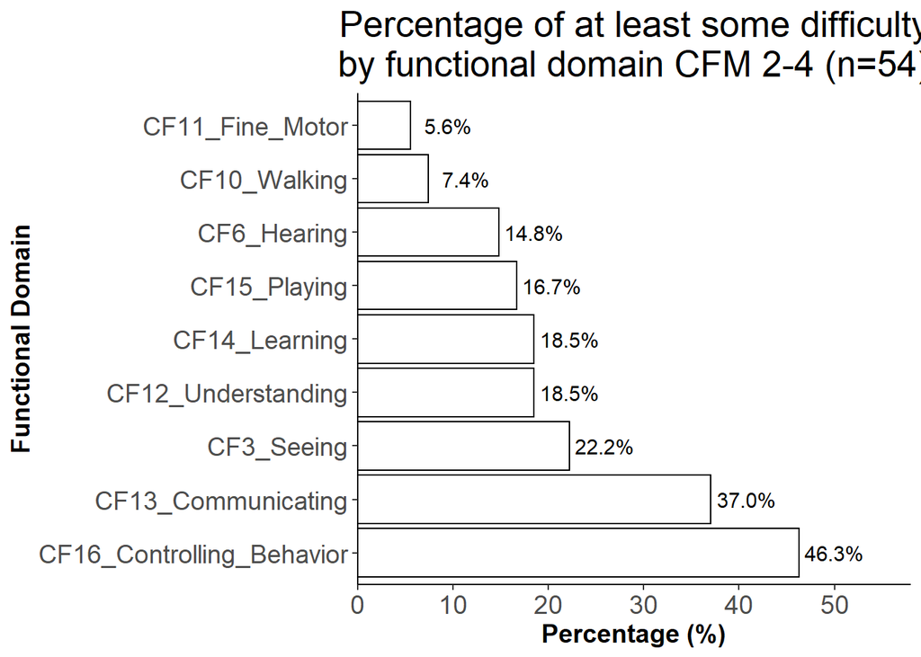

|  | 0 | 1 |
| --- | --- | --- |
| CF10_Walking | 50 | 4 |
| CF11_Fine_Motor | 51 | 3 |
| CF12_Understanding | 44 | 10 |
| CF13_Communicating | 34 | 20 |
| CF14_Learning | 44 | 10 |
| CF15_Playing | 45 | 9 |
| CF16_Controlling_Behavior | 29 | 25 |
| CF3_Seeing | 42 | 12 |
| CF6_Hearing | 46 | 8 |

## Part 2: Predicting difficulty Model (CFM2_4) from DD children

- This is going to be a generalized linear mixed effects model with a binomial distribution and fixed effects of age, domain, sex, domain * sex in predicting having or not having a reported difficulty (0,1).
- Child_ID will have their own random intercept
- HOH_ID initially was going to have a random intercept but the empty model indicated a variance of 0- thus it was decided it would not be necessary.
- Model comparison using `anova()` will inform us which model will be best to use.
- Covariates that do not add any benefit to the model will be removed
- Significant multilevel factors or interactions will be investigated using estimated marginal means and pairwise comparisons with p values adjusted for by false discovery rate to correct for multiple compairson.

```
[1] 54
```

```
# Intraclass Correlation Coefficient

    Adjusted ICC: 0.039
  Unadjusted ICC: 0.039
```

```
Data: CFM2_4_vars2_DD_long
Models:
CFM2_4_empty: Reported_Difficulty ~ 1 + (1 | Child_ID)
CFM2_4_covariate: Reported_Difficulty ~ Child_age + (1 | Child_ID)
CFM2_4_covariate2: Reported_Difficulty ~ Child_age + Child_Gender + (1 | Child_ID)
CFM2_4_main: Reported_Difficulty ~ Child_age + Child_Gender + Domain + (1 | Child_ID)
CFM2_4_complex: Reported_Difficulty ~ Child_age + Child_Gender * Domain + (1 | Child_ID)
                  npar    AIC    BIC  logLik deviance   Chisq Df Pr(>Chisq)
CFM2_4_empty         2 499.77 508.14 -247.89   495.77
CFM2_4_covariate     3 499.77 512.33 -246.88   493.77  2.0039  1     0.1569
CFM2_4_covariate2    4 501.74 518.49 -246.87   493.74  0.0263  1     0.8711
CFM2_4_main         12 471.71 521.94 -223.85   447.71 46.0341  8  2.342e-07 ***
CFM2_4_complex      20 481.93 565.66 -220.97   441.93  5.7740  8     0.6725
---
Signif. codes:  0 '***' 0.001 '**' 0.01 '*' 0.05 '.' 0.1 ' ' 1
```

```
Analysis of Deviance Table (Type III Wald chisquare tests)

Response: Reported_Difficulty
             Chisq Df Pr(>Chisq)
(Intercept) 24.424  1  7.732e-07 ***
Domain      39.533  8  3.914e-06 ***
---
Signif. codes:  0 '***' 0.001 '**' 0.01 '*' 0.05 '.' 0.1 ' ' 1
```

```
                          CF10_Walking CF11_Fine_Motor CF12_Understanding
CF10_Walking                  [-2.627]          0.7804             0.1543
CF11_Fine_Motor               0.311802        [-2.939]             0.0979
CF12_Understanding           -1.071319       -1.383121           [-1.556]
CF13_Communicating           -2.067267       -2.379069          -0.995948
CF14_Learning                -1.071584       -1.383387          -0.000266
CF15_Playing                 -0.939225       -1.251028           0.132093
CF16_Controlling_Behavior    -2.471973       -2.783775          -1.400654
CF3_Seeing                   -1.309505       -1.621307          -0.238186
CF6_Hearing                  -0.794792       -1.106594           0.276527
                          CF13_Communicating CF14_Learning CF15_Playing
CF10_Walking                          0.0040        0.1543       0.2226
CF11_Fine_Motor                       0.0040        0.0979       0.1489
CF12_Understanding                    0.0779        0.9996       0.8196
CF13_Communicating                  [-0.560]        0.0779       0.0528
CF14_Learning                       0.995682      [-1.555]       0.8196
CF15_Playing                        1.128041      0.132359     [-1.688]
CF16_Controlling_Behavior          -0.404706     -1.400388    -1.532747
CF3_Seeing                          0.757761     -0.237921    -0.370280
CF6_Hearing                         1.272475      0.276793     0.144434
                          CF16_Controlling_Behavior CF3_Seeing CF6_Hearing
CF10_Walking                                 0.0006     0.0831      0.3323
CF11_Fine_Motor                              0.0006     0.0528      0.1954
CF12_Understanding                           0.0096     0.7262      0.7262
CF13_Communicating                           0.4373     0.1543      0.0315
CF14_Learning                                0.0096     0.7262      0.7262
CF15_Playing                                 0.0063     0.6096      0.8196
CF16_Controlling_Behavior                  [-0.155]     0.0315      0.0040
CF3_Seeing                                 1.162468   [-1.317]      0.4373
CF6_Hearing                                1.677181   0.514714    [-1.832]

Row and column labels: Domain
Upper triangle: P values   adjust = "fdr"
Diagonal: [Estimates] (emmean)
Lower triangle: Comparisons (estimate)   earlier vs. later
```

### Interpretation of the results from above

- We used model comparison to test the following models against each other
  - Mod0 (Empty model) (Child_ID with random intercept)
  - Mod1: Age
  - Mod2: Age and Sex
  - Mod3: Age, Sex, Domain
  - Mod4 (Complex): Age, Sex, Domain, Sex * Domain

We used model comparison and noticed only that model 3 was the only model significantly different from the empty model, indicating the covariates did not have any predictive power. Additionally, the more complex model (model 4) did not explain more of the variance than model 3, thus this was the best choice. On closer inspection of model 3, there was a warning with the model failing to converge and producing a gradient value of `0.0312462`. This is extremely problematic since the tolerance threshold is set to `0.002` and any values larger than this will produce unreliable estimates and standard errors. Thus, a new model was created that only ensured the levels of domain and it produced a gradient value of `0.00230779`. While it is still larger than the threshold, we can argue that it is close enough and still put some trust in the estimates, which is what we will be doing.

Using Wald Chi Square Tests with type III SS we see there is a significant fixed effect of Domain (χ2(8)= 39.53, p <.001). Follow up tests on the estimated marginal means through pairwise comparisons showed larger log odds of reporting communication problems than walking (p <.01) and fine motor movement (p <.01).Additionally, controlling behavior was the most frequently reported difficulty, with having higher log odds than walking (p < .001), fine motor movements (p < .001), understanding (p <.01), learning (p <.01), and playing (p <.01) but not communicating (p = .44). These results show that motor movements tend to be less frequent in children 2_4 years old and the most common difficulty is in controlling behavior, which seems to be expected.